# Lesson 170 · Defend a relational FM design

Portable CPU-only saved-evidence replay: Python3 + NumPy, no downloads or cloud calls. Tier B real relational evidence. Synthetic CHECK data only isolates mechanisms. PROVIDED code authenticates raw files; your three TODO functions determine the report. CHECK gives feedback; EXIT requires your own written defense. This is author preparation, not learner mastery.

**Your task:** write a defensible design for one relational prediction problem. Choose a representation, a pretrained predictor and a target-adaptation rule. Attach evidence for the claims you make, and name an experiment that could change your mind.

**Reading route.** First recall the three decisions below. Then replay the evidence, inspect where the comparison reverses, and complete the design template. The core reading takes about 25 minutes; leave a separate session for the lab and written defense. Preparation is complete only when the artifacts pass their checks. Your checkpoint remains **PENDING_WRITTEN_DEFENSE** until you submit your own work for review.

[Open the lab](https://avistian.github.io/relational/labs/html/0170-fm-design-checkpoint.html) · [Student notebook](https://avistian.github.io/relational/labs/0170-fm-design-checkpoint.ipynb) · [Reference solution](https://avistian.github.io/relational/labs/solutions/0170-fm-design-checkpoint.ipynb) · [Design template](https://avistian.github.io/relational/labs/l170-design-template.md) · [Quick reference](https://avistian.github.io/relational/reference/fm-design-checkpoint.html)

## 1 · From measuring a curve to making a decision

[Lesson 167](https://avistian.github.io/relational/lessons/0167-tabular-to-relational-fm-transfer.html) separated representation, pretraining and adaptation. [Lesson 168](https://avistian.github.io/relational/lessons/0168-cross-database-generalization.html) added a second task. [Lesson 169](https://avistian.github.io/relational/lessons/0169-scaling-laws-open-questions.html) varied context size while keeping pretrained weights fixed. Those experiments tell us what happened under their protocols. They do not automatically choose an architecture for a new database.

> **In plain terms.** A design document connects “what the system must do” to “why this method is a reasonable starting point” and “what would make us reject it.” A small measured gain can justify another experiment without justifying deployment.

**Prerequisite recap.** A relational database stores entities and events in linked tables. A foreign key names a related row. A query key is the pair **(entity, cutoff)**: who receives a prediction, and when. Features must use information available by that cutoff. A label describes the future outcome to predict. A training label may be used only after its outcome window has closed and it is available.

A **foundation model** has reusable pretrained parameters. **Pretraining** learns those parameters before the target task. **Adaptation** makes the predictor useful on the target task. Adaptation can update weights or supply labeled examples as inputs. **In-context learning (ICL)** uses such examples while keeping predictor weights fixed. A **support set** is that collection of labeled examples. Its size is K. These definitions let us compare methods without treating every use of “foundation model” as the same mechanism. [Vogel vision paper](https://arxiv.org/html/2305.15321v1), [Griffin §4](https://arxiv.org/html/2505.05568v1#S4), [RDB-PFN v5](https://arxiv.org/html/2603.03805v5).

## 2 · Three independent design decisions

**Representation: what information reaches the predictor?** A graph representation retains rows and key links, then learns how neighboring rows communicate. A materialized feature table summarizes linked records into columns before prediction. **Deep Feature Synthesis (DFS)** composes joins, transformations and aggregations into those columns. Here “deep” describes compositions; it does not imply a deep neural encoder.

**Prior: what was learned before this task?** A prior is a learned preference for certain relationships before observing target labels. Griffin learns transferable graph and cell operations through source-task supervision. RDB-PFN learns from synthetic tasks with relational structure. RDBLearn uses an already pretrained tabular predictor after relational featurization. [Griffin §§3–4](https://arxiv.org/html/2505.05568v1#S3), [RDB-PFN §§4–5](https://arxiv.org/html/2603.03805v5), [RDBLearn §3](https://arxiv.org/html/2602.18495v1#S3).

**Adaptation: where do target labels enter?** Griffin's supervised transfer route fine-tunes weights on a target task. The RDB-PFN and tabular-ICL routes studied here feed support labels to a fixed predictor. “Training-free” describes the target-time use of the pretrained predictor, not an absence of pretraining, labels, preprocessing or computational cost.

**Which Griffin weights change?** The shared cell-reading and graph-message operations adapt; the released input encoders and task decoder stay frozen. Classification compares the adapted root state with frozen label vectors. This is why the diagram ends with a frozen decoder even though the overall target-task route performs fine-tuning. Return to [Lesson 164's architecture](https://avistian.github.io/relational/lessons/0164-griffin-graph-centric-rdb-fm.html) for the complete path.

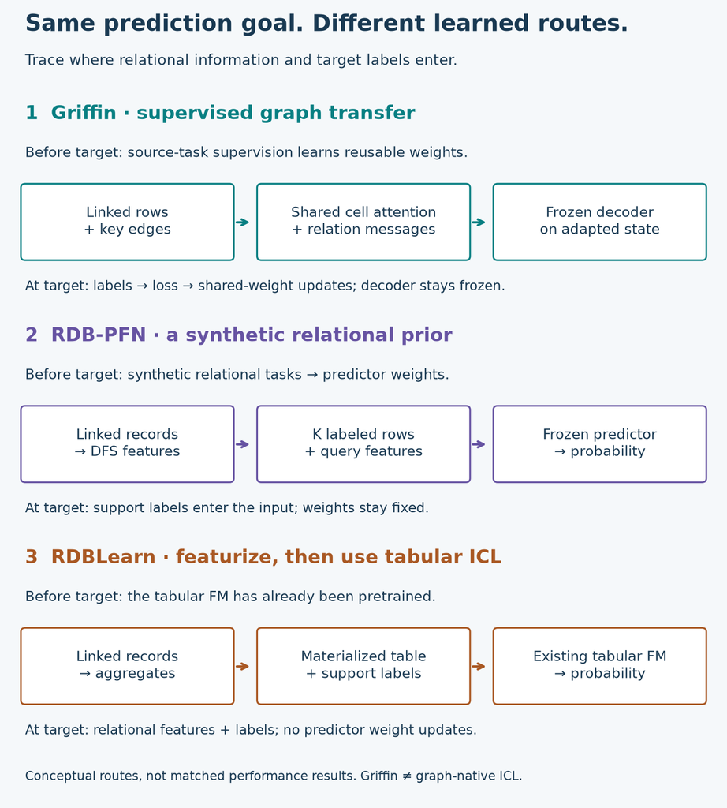

Trace the target labels: Griffin updates target weights; the two ICL routes supply labels as inputs. RDBLearn is a pipeline approach, not an extra model arm in this replay. On narrow screens, scroll the diagram horizontally.

| Candidate | Why consider it? | What could break the choice? | Evidence we actually have |
| --- | --- | --- | --- |
| Griffin graph transfer | Learned messages can preserve relationships that fixed aggregates discard | Supervised adaptation cost; insufficient labels; temporal graph errors | L164 mechanism/source checks; fresh selected experiment stopped at its budget gate |
| RDB-PFN | Synthetic relational tasks may provide a useful prior for small labeled contexts | Prior mismatch; lost information in DFS; unverified exposure lineage | Complete selected released-checkpoint evidence on two tasks across five contexts |
| RDBLearn approach | Relational aggregates plus an existing tabular ICL predictor offer a direct baseline | Aggregations may omit the relevant relation; feature generation may dominate cost | Primary-paper evidence; our DFS + TabICL arm illustrates the approach but is not the RDBLearn pipeline |

These are candidate reasons and failure hypotheses, not a ranking across three matched implementations. Griffin is graph-centric, but its fine-tuning route is not graph-native ICL. KumoRFM in [Lesson 165](https://avistian.github.io/relational/lessons/0165-kumorfm-in-context-relational-learning.html) provides a separate graph-native ICL comparison; its proprietary historical pipeline was not reproduced. You do not need the optional 165b, 166b or 170b lessons to complete this checkpoint.

**Worked example — where the label goes.** Suppose a fixed predictor reads 512 past labeled driver queries and predicts 702 new queries. It takes zero gradient steps. This is labeled-context adaptation, not a zero-label experiment. By contrast, a supervised model that updates its weights on those labels uses target training. The lab's classifier covers this supervised setting; it does not classify unsupervised or self-supervised target adaptation.

## 3 · Reproduce the evidence before using it

Our named experiment is the **complete saved-evidence replay of L169's selected RDB-PFN v5 Tables 6–10**. The selection contains all five contexts (64, 128, 256, 512, 1024), all ten support seeds, all three fixed models, and every test query on **rel-f1/driver-dnf (702)** and **rel-trial/study-outcome (825)**. This gives **300 evaluations and 229,050 probabilities**. [Paper Appendix A.3 and Tables 6–10](https://arxiv.org/html/2603.03805v5#A6).

**Held fixed:** released checkpoints, feature arrays, preprocessing, test populations and source versions. Within each task/context/seed, all models receive the same support identities. The third model is the single-table-pretrained RDB-PFN ablation. **Varied:** context size and predictor. **Measured:** ranking quality and paired differences. Support sets at different K are independently drawn by the source sampler; equal seed numbers do not make them nested prefixes. Nothing in this experiment varies pretraining scale.

**AUROC** is the probability that a positive example receives a higher score than a negative example, giving half credit to ties. It is a ranking metric, not a measure of probability calibration. We align predictions by full query key before scoring. The local audit also checks hashes, original per-run receipts, support labels, raw labels and the complete experiment grid. A separate sklearn calculation checks all 300 scores.

> **Scope check.** All 300 evaluations are reused in L170. Of these, 240 were fresh in L169 and 60 came from L166/L168. L170 runs no new inference or training. The full replay is executable and complete for this selection; whole-paper reproduction and fresh pretraining remain **NOT_RUN**. [Exact protocol and commands](https://avistian.github.io/relational/labs/l170-reproduction.md).

Before inspecting the results, predict whether a positive mean gain at K=512 must persist at K=128. Explain your answer.

### Pair first, then average

**Worked example.** On one task, suppose model A scores .72 and .68 on seeds 0 and 1, while B scores .70 and .69. Paired gains are +.02 and −.01. The mean gain is +.005; A wins on only one of the two draws. Keeping the pairs exposes a reversal that a single mean conceals.

For each task and K, calculate ten differences **Δs = AUROC(RDB-PFN, s) − AUROC(TabICL, s)**. The symbol s indexes the support draw. Average those differences, count how many are positive, and compute their **sample standard deviation**, the square root of squared deviations from the mean divided by 9. This describes sensitivity to support draws on a fixed task. It is not a confidence interval over unseen databases.

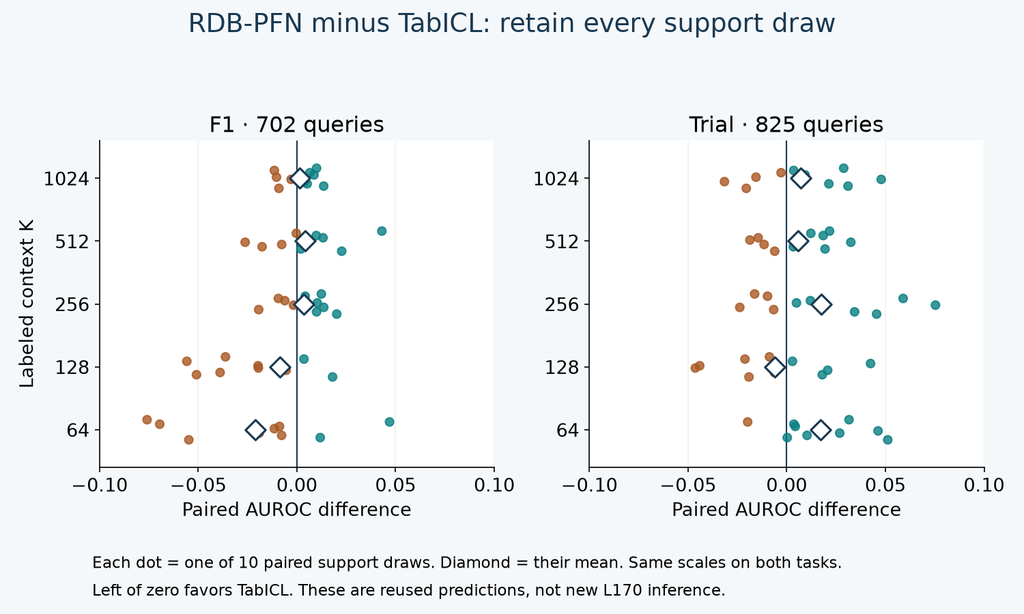

Each dot is one paired support draw; the white diamond is the mean. Zero and identical horizontal scales expose sign reversals. All 100 differences come from reused raw predictions. Scroll horizontally on narrow screens.

| Context K | F1 gain ± SD | Positive draws | Trial gain ± SD | Positive draws |
| --- | --- | --- | --- | --- |
| 64 | -0.02098 ± 0.03744 | 2/10 | +0.01707 ± 0.02199 | 9/10 |
| 128 | -0.00863 ± 0.05041 | 3/10 | -0.00612 ± 0.02829 | 4/10 |
| 256 | +0.00343 ± 0.01228 | 6/10 | +0.01752 ± 0.03414 | 6/10 |
| 512 | +0.00437 ± 0.01981 | 6/10 | +0.00574 ± 0.01765 | 6/10 |
| 1024 | +0.00142 ± 0.00915 | 6/10 | +0.00719 ± 0.02538 | 6/10 |

Gain = RDB-PFN minus TabICL AUROC. SD describes support-draw variation within each fixed task. All numbers are authenticated author-reference evidence, not learner results.

For a summary across these two tasks, give each task one equal weight. Do not concatenate probabilities from unrelated tasks or weight the task gains by their query counts. The lab requires all 300 cells before calculating the comparison, so silently dropping an inconvenient context or seed is rejected.

In the first TODO below, implement the complete-grid comparison, retaining task/context/seed identity.

**Interpretation.** At K=512, RDB-PFN's mean advantage is positive on both tasks, but only six of ten support draws are positive in each. At K=64 it loses on F1 and wins on trial; at K=128 both mean differences are negative. This is a reason to test context sensitivity. Selecting the best K from these test results would turn descriptive analysis into test-set tuning. In a future experiment, freeze K using validation data before evaluating test results.

**Worked decision trap: choosing context after seeing test results.** The authenticated equal-task mean gains over TabICL are:

| Context K | Mean AUROC gain | Meaning |
| --- | --- | --- |
| 128 | −0.007372 | TabICL ahead on average |
| 256 | +0.010474 | RDB-PFN ahead on average |

Choosing 256 after inspecting these test results changes the displayed advantage by about **0.017846 AUROC** relative to 128. That arithmetic is valid descriptive analysis; the same test set can no longer provide an independent evaluation of the newly selected context policy. **Transfer check:** if validation had selected 128 before test scores were revealed, keep its negative test result as the selected-policy result. Report the full sweep separately. A disappointing test outcome does not authorize replacing the frozen policy.

## 4 · Audit the claim, not just the arithmetic

A trustworthy replay can still sit inside an incomplete scientific comparison. The original released labels are complements of the pinned raw task labels; the saved experiment consistently retains the released orientation. Available support-horizon and selected timestamp checks passed, but these are not a complete audit of historical information availability. Full DFS regeneration was not run. Exact target-schema exclusion and checkpoint training lineage remain unestablished.

The exact-repeatability diagnostic also stays visible: four RDB-PFN repeats matched exactly; two TabICL repeats differed, with maximum probability difference about .0002791 and maximum AUROC difference about .00000488. The cause was not isolated. The original accepted predictions remain in the comparison; we do not choose whichever repeat scores best or invent a new tolerance after observing the difference. [Original diagnostics](https://avistian.github.io/relational/labs/evidence/l169/recovery-report.json).

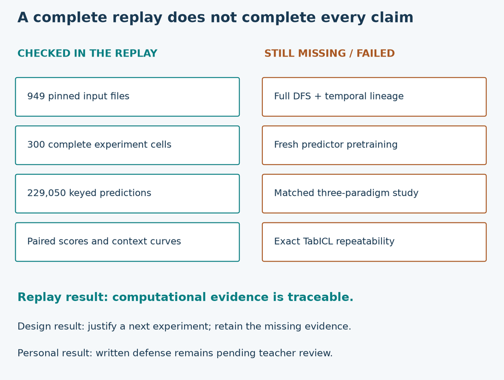

The replay authenticates computations. Missing pipeline and pretraining evidence still constrain a design. The exact-repeatability failure remains visible. Scroll horizontally on narrow screens.

**How to read a gate.** “Artifacts” means byte-level identity was checked. “Metrics” means raw predictions were independently rescored. “Temporal” here requires the complete information-availability audit, so it remains false even though narrower checks passed. “Exposure” requires the relevant pretraining and schema-source inventory. “Matched pipeline” means the compared systems ran under the same declared evaluation contract. “Held-out databases” means an adequate, prespecified multi-database evaluation for the intended claim; two selected tasks alone do not certify a general advantage.

Authenticated baseline: artifacts and metrics are checked. Full DFS, temporal availability, exposure, fresh pretraining, matched pipelines, adequate database generalization and exact repeatability prerequisites are not all met. Use your claim_gate function below to explore hypothetical declarations.

The explorer is a **hypothetical evidence checklist**. Checking a box does not create that evidence or change the authenticated report. **READY_FOR_REVIEW** means the listed necessary prerequisites are present; a reviewer must still assess results, uncertainty and relevance. It is never an automatic declaration that one paradigm wins.

## 5 · Write the design that the evidence can support

Choose either a real task you can document or the worked F1 task as a planning exercise. For F1, preserve the released binary-label orientation and identify exactly which event that label represents. Do not invent a business requirement and report it as observed.

Your 500–800-word design should contain these eight short sections. The [template](https://avistian.github.io/relational/labs/l170-design-template.md) includes prompts and a submission checklist.

1. **Decision and task.** Who is scored, at what cutoff, for which future outcome, and what decision uses the score? Name the metric and operational constraints.
2. **Information contract.** State key paths, feature availability and support-label readiness. Separate observed checks from unresolved assumptions.
3. **Candidates.** Compare the three paradigms on representation, pretraining and adaptation. Explain why the chosen candidate is feasible and why at least one alternative might still win.
4. **Evidence.** Cite a task/context/seed comparison from the replay. Explain one reversal and the correct uncertainty unit. Keep RDBLearn and Griffin gaps explicit.
5. **Proposed experiment.** Specify fixed splits, matched labels/supports, preprocessing, validation-only selection, repeated seeds and a suitable supervised baseline. Charge feature generation and adaptation to each pipeline.
6. **Falsifier.** Name a measurable outcome that would make you change the design. Declare the threshold before running the new experiment.
7. **Cost and stop rule.** Include preparation, all seeds, retries and checks under an aggregate cap. If the complete protocol does not fit, stop and report incomplete work.
8. **Limitations and next step.** State which conclusion is currently justified and which one remains a hypothesis.

**Example of the reasoning, not a completed submission.** If target-time weight updates are prohibited but historical labels are available, start by comparing the two labeled-context routes. The replay supports evaluating RDB-PFN against a DFS + TabICL baseline. It does not establish that either is better than a fully audited graph pipeline. A useful next experiment would compare complete pipelines on prespecified held-out tasks with temporal audits and a fixed context policy. A nonpositive paired gain under that protocol could challenge the extra complexity of the relational prior. Its exact population, decision threshold and budget must be frozen before execution.

**Rubric: 0–2 on each axis.** Task/temporal contract; paradigm accuracy; evidence and uncertainty; fair falsifiable experiment; cost and limitations. Zero means absent or materially wrong, one means plausible but incomplete, two means concrete and defensible. Target **at least 8/10 with no zero**, plus passing computational checks and teacher review. A runnable solution or a filled template cannot certify your understanding. No Year 4 gate is changed by this checkpoint.

Write your defense before consulting the template outline. Ask the teacher to challenge its weakest evidence.

## Lab and primary reading

The portable notebook embeds original evidence and visible audit code. Implement the three live functions, run their checks, replay every prediction, and submit the computed report together with your written design. The teacher solution leaves the personal defense blank. The default requires Python and NumPy, uses CPU only, and makes no network or cloud calls. Author validation adds sklearn as an independent scorer.

Primary reading: [RDB-PFN v5 Appendix A.3 and Tables 6–10](https://arxiv.org/html/2603.03805v5#A6), alongside [Griffin §§3–4](https://arxiv.org/html/2505.05568v1#S3) and [RDBLearn §§3–5](https://arxiv.org/html/2602.18495v1#S3). Revisit [Vogel's vision](https://arxiv.org/html/2305.15321v1) to distinguish an architectural research agenda from executed evidence. The versioned source snapshots and hashes are in the [source ledger](https://avistian.github.io/relational/labs/sources/l170/source-ledger.json).

Ask the teacher about any unclear mechanism or bring your defense back for a challenge: “Which claim in my design has the weakest evidence?” Revisit the same question after the next corpus-design lesson, without rereading your answer first.

```python
# @colab-bootstrap
import os
os.environ.update(OMP_NUM_THREADS="1",OPENBLAS_NUM_THREADS="1",MKL_NUM_THREADS="1")
import base64,hashlib,io,json,zipfile
from pathlib import Path
import numpy as np
P=Path("l170-portable");P.mkdir(exist_ok=True)
```

## PROVIDED · Original raw evidence

Authenticate source snapshots, released arrays, supports, original per-run receipts and all selected prediction files. The original saved report is included only as a parity target; all metrics below are recomputed from raw predictions. Original L169 diagnostics are retained separately from experiment cells.

```
Authenticated packet: 300 evaluation cells; 229,050 probabilities to rescore
```

## PROVIDED · Full-key AUROC

Visible canonical code from the aligned earlier experiment. Source checks compare these function bodies with their pinned originals. This checkpoint reuses the existing model evaluation and audits all outputs.

```python
def keyed_auc(expected_keys, labels, prediction_keys, probabilities):
    """Align exact composite identities; AUROC from average ranks (ties=half)."""
    import numpy as np
    expected=np.asarray(expected_keys);got=np.asarray(prediction_keys)
    y=np.asarray(labels);p=np.asarray(probabilities,dtype=float)
    for keys in (expected,got):
        if keys.ndim!=2 or keys.shape[1]!=2 or len(set(map(tuple,keys)))!=len(keys):
            raise ValueError('Duplicate or malformed composite keys')
    if y.shape!=(len(expected),) or p.shape!=(len(got),) or set(y)!={0,1}:
        raise ValueError('Invalid label/prediction population')
    if not np.isfinite(p).all() or np.any((p<0)|(p>1)):
        raise ValueError('Invalid class-1 probabilities')
    lookup=dict(zip(map(tuple,got),p))
    if set(lookup)!=set(map(tuple,expected)):raise ValueError('Incomplete or extra query keys')
    scores=np.array([lookup[tuple(key)] for key in expected])
    order=np.argsort(scores,kind='stable');sorted_scores=scores[order]
    ranks=np.empty(len(scores),dtype=float);i=0
    while i<len(scores):
        j=i+1
        while j<len(scores) and sorted_scores[j]==sorted_scores[i]:j+=1
        ranks[order[i:j]]=(i+1+j)/2.;i=j
    positives=int(y.sum());negatives=len(y)-positives
    return float((ranks[y==1].sum()-positives*(positives+1)/2)/(positives*negatives))
```

## PROVIDED · Original support sampler and context curves

Visible canonical code from the aligned earlier experiment. Source checks compare these function bodies with their pinned originals. This checkpoint reuses the existing model evaluation and audits all outputs.

```python
def sample_context(n_rows,context,seed_key):
    import hashlib
    import numpy as np
    if type(n_rows) is not int or type(context) is not int or not 0<context<=n_rows or not isinstance(seed_key,str) or not seed_key:
        raise ValueError('Invalid context request')
    integer=int.from_bytes(hashlib.sha256(seed_key.encode()).digest()[:4],'big')
    return np.random.default_rng(integer).choice(n_rows,context,replace=False)
```

```python
def scaling_curve(records):
    import numpy as np
    contexts=[64,128,256,512,1024];seeds=list(range(10));values={}
    for r in records:
        k,s=r['context'],r['seed'];v=float(r['auc'])
        if type(k) is not int or type(s) is not int or k not in contexts or s not in seeds or (k,s) in values or not np.isfinite(v) or not 0<=v<=1:
            raise ValueError('Invalid or duplicate curve point')
        values[k,s]=v
    if set(values)!={(k,s) for k in contexts for s in seeds}:raise ValueError('Incomplete curve')
    levels=[];doublings=[]
    for i,k in enumerate(contexts):
        a=np.array([values[k,s] for s in seeds])
        levels.append(dict(context=k,per_seed=a.tolist(),mean=float(a.mean()),sample_sd=float(a.std(ddof=1))))
        if i:
            delta=a-np.array([values[contexts[i-1],s] for s in seeds])
            doublings.append(dict(start=contexts[i-1],end=k,per_seed=delta.tolist(),mean_gain=float(delta.mean()),sample_sd=float(delta.std(ddof=1)),positive_seeds=int((delta>0).sum())))
    return dict(levels=levels,doublings=doublings,interpretation='SUPPORT_DRAW_VARIATION_ON_ONE_FIXED_TASK')
```

```python
def scaling_claim(axis,controlled,levels,extrapolating):
    if axis not in ['context','parameters','pretraining_data','schema_diversity'] or type(controlled) is not bool or type(extrapolating) is not bool or type(levels) is not int or levels<1:
        raise ValueError('Invalid evidence declaration')
    if not controlled:return 'CONFOUNDED'
    if levels<2:return 'INSUFFICIENT_LEVELS'
    if extrapolating:return 'EXTRAPOLATION_NOT_ESTABLISHED'
    if axis=='context':return 'CONTEXT_RESPONSE_ONLY'
    return 'CONTROLLED_SWEEP_NOT_LAW'
```

## PROVIDED · Original source/receipt/query audit

Visible canonical code from the aligned earlier experiment. Source checks compare these function bodies with their pinned originals. This checkpoint reuses the existing model evaluation and audits all outputs.

```python
def audit169(root,pins,auc_fn,sample_fn,curve_fn,claim_fn):
    import hashlib,json
    from pathlib import Path
    import numpy as np
    root=Path(root)
    for name,digest in pins['files'].items():
        if hashlib.sha256((root/name).read_bytes()).hexdigest()!=digest:raise ValueError('Artifact hash mismatch: '+name)
    manifest=json.loads((root/'evidence/l169/input-manifest.json').read_text())
    original=json.loads((root/'sources/l166/source-ledger.json').read_text())
    for name,digest in manifest['source_files'].items():
        if digest!=original['files'][name.removeprefix('sources/l166/')]:raise ValueError('Original source ledger differs')
        if pins['files'][name]!=digest:raise ValueError('Source pin differs')
    for db in manifest['experiments']:
        name=db['database']+'.npz'
        if pins['files']['evidence/l169/'+name]!=manifest['files'][name]['sha256']:raise ValueError('Input data pin differs')
    rows=[];raw_count=0;fresh_count=0;reused_count=0;seen=set();curves={};pairs={};comparisons=[];support_overlaps={}
    for spec in manifest['experiments']:
        db=spec['database'];data=np.load(root/'evidence/l169'/(db+'.npz'),allow_pickle=False)
        keys=data['test_keys'];labels=data['y_test'];train=data['train_keys'];oldfolder=root/spec['original_folder'];old=json.loads((oldfolder/'input-manifest.json').read_text())
        olddata=np.load(oldfolder/'prepared.npz',allow_pickle=False)
        if hashlib.sha256((oldfolder/'prepared.npz').read_bytes()).hexdigest()!=old['files']['prepared.npz']['sha256']:raise ValueError('Original data hash mismatch')
        for key in ['X_train','X_test','y_train','y_test','train_keys','test_keys']:
            if not np.array_equal(data[key],olddata[key],equal_nan=True):raise ValueError('Changed original task array: '+key)
        if len(keys)!=spec['test_rows'] or len(train)!=spec['train_rows'] or data['X_test'].shape!=(len(keys),spec['features']):raise ValueError('Wrong task shape')
        if len(set(map(tuple,keys)))!=len(keys) or len(set(map(tuple,train)))!=len(train) or set(map(tuple,keys))&set(map(tuple,train)):raise ValueError('Invalid query keys')
        horizon=(60 if db=='rel-f1' else 365)*86400*10**9
        if not (train[:,1]+horizon<keys[:,1].min()).all():raise ValueError('Support labels not ready')
        for k in manifest['contexts']:
            schedule=data['support_'+str(k)]
            if schedule.shape!=(10,k):raise ValueError('Incomplete support schedule')
            for seed in range(10):
                expected=sample_fn(len(train),k,spec['seed_key'].format(seed=seed))
                if not np.array_equal(schedule[seed],expected):raise ValueError('Different support schedule')
            if k==512 and not np.array_equal(schedule,olddata['support']):raise ValueError('Reused supports differ')
        support_overlaps[db]=[dict(start=a,end=b,overlap_counts=[len(set(data['support_'+str(a)][s])&set(data['support_'+str(b)][s])) for s in range(10)]) for a,b in zip(manifest['contexts'][:-1],manifest['contexts'][1:])]
        sources=[(oldfolder/phase,512,True) for phase in spec['original_phases']]+[(root/'evidence/l169'/phase,None,False) for phase in ['pilot-1','remaining-complete']]
        for folder,fixed_k,reused in sources:
            receipt=json.loads((folder/'receipt.json').read_text())
            expected_manifest=oldfolder/'input-manifest.json' if reused else root/'evidence/l169/input-manifest.json'
            if receipt['input_manifest_sha256']!=hashlib.sha256(expected_manifest.read_bytes()).hexdigest():raise ValueError('Receipt input differs')
            for r in receipt['records']:
                if not reused and r['database']!=db:continue
                k=fixed_k if reused else r['context'];arm=r['arm'];seed=r['seed'];identity=(db,arm,k,seed)
                if type(seed) is not int or type(k) is not int or arm not in manifest['arms'] or k not in manifest['contexts'] or seed not in range(10) or identity in seen:raise ValueError('Invalid or duplicate run')
                if not reused and k==512:raise ValueError('512 context must be authenticated reused evidence')
                seen.add(identity);path=folder/(f'{arm}-{seed}.npz' if reused else f'{db}-{arm}-{k}-{seed}.npz')
                if hashlib.sha256(path.read_bytes()).hexdigest()!=r['sha256']:raise ValueError('Receipt prediction hash differs')
                if not reused and 'origin_phase' in r:
                    origin=root/'evidence/l169'/r['origin_phase']/r['filename']
                    if hashlib.sha256(origin.read_bytes()).hexdigest()!=r['sha256']:raise ValueError('Original shard hash differs')
                    record_path=origin.with_suffix('.json')
                    if hashlib.sha256(record_path.read_bytes()).hexdigest()!=r['origin_record_sha256']:raise ValueError('Original per-run receipt differs')
                    original_record=json.loads(record_path.read_text())
                    if any(r.get(key)!=value for key,value in original_record.items()):raise ValueError('Assembled record changed original fields')
                with np.load(path,allow_pickle=False) as out:
                    if not np.array_equal(out['support_keys'],train[data['support_'+str(k)][seed]]):raise ValueError('Support identities differ')
                    if len(out['keys'])!=len(keys) or len(set(map(tuple,out['keys'])))!=len(keys):raise ValueError('Incomplete prediction keys')
                    if dict(zip(map(tuple,out['keys']),out['label']))!=dict(zip(map(tuple,keys),labels)):raise ValueError('Wrong keyed labels')
                    auc=auc_fn(keys,labels,out['keys'],out['probability'])
                    if abs(auc-r['auc'])>1e-12:raise ValueError('Metric receipt differs')
                rows.append(dict(database=db,arm=arm,context=k,seed=seed,auc=auc,evidence='REUSED' if reused else 'FRESH'))
                raw_count+=len(keys);fresh_count+=not reused;reused_count+=reused
        for arm in manifest['arms']:
            curve=curve_fn([r for r in rows if r['database']==db and r['arm']==arm]);curves[db+'/'+arm]=curve
            for level in curve['levels']:
                k=level['context'];target=manifest['paper_targets'][str(k)][arm][db];delta=level['mean']-target
                comparisons.append(dict(database=db,arm=arm,context=k,mean=level['mean'],sample_sd=level['sample_sd'],paper=target,delta=delta,status='CLOSE' if abs(delta)<=manifest['descriptive_tolerance'] else 'OUTSIDE_TOLERANCE',evidence='REUSED' if k==512 else 'FRESH'))
        for k in manifest['contexts']:
            a={r['seed']:r['auc'] for r in rows if r['database']==db and r['arm']=='RDBPFN' and r['context']==k}
            b={r['seed']:r['auc'] for r in rows if r['database']==db and r['arm']=='TabICLv1.1' and r['context']==k}
            delta=np.array([a[s]-b[s] for s in range(10)])
            pairs[db+'/'+str(k)]=dict(per_seed=delta.tolist(),mean=float(delta.mean()),sample_sd=float(delta.std(ddof=1)),positive_seeds=int((delta>0).sum()))
    expected={(d['database'],a,k,s) for d in manifest['experiments'] for a in manifest['arms'] for k in manifest['contexts'] for s in range(10)}
    if seen!=expected or fresh_count!=240 or reused_count!=60:raise ValueError('Incomplete selected experiment')
    recovery=json.loads((root/'evidence/l169/remaining-complete/receipt.json').read_text())
    sentinel_checks=[]
    for record in json.loads((root/'evidence/l169/tail-1/receipt.json').read_text())['records']:
        if record['context']!=64:continue
        name=record['filename']
        with np.load(root/'evidence/l169/remaining-2'/name) as a,np.load(root/'evidence/l169/tail-1'/name) as b:
            for field in ['keys','label','support_keys']:
                if not np.array_equal(a[field],b[field]):raise ValueError('Sentinel identity mismatch')
            delta=float(np.max(np.abs(a['probability']-b['probability'])))
            aa=auc_fn(a['keys'],a['label'],a['keys'],a['probability']);bb=auc_fn(b['keys'],b['label'],b['keys'],b['probability'])
            sentinel_checks.append(dict(database=record['database'],arm=record['arm'],max_probability_difference=delta,auc_difference=bb-aa,exact_probability_match=delta==0))
    if len(sentinel_checks)!=6:raise ValueError('Incomplete sentinel diagnostics')
    for a,b in zip(sentinel_checks,recovery['sentinel_results']):
        if any(abs(a[k]-b[k])>1e-12 for k in ['max_probability_difference','auc_difference']) or a['arm']!=b['arm'] or a['database']!=b['database']:raise ValueError('Sentinel diagnostic differs')
    return dict(experiment=manifest['experiment'],status='COMPLETE_SELECTED_CONTEXT_SWEEP',fresh_runs=fresh_count,reused_runs=reused_count,all_predictions_checked=raw_count,
                exact_repeatability='PASS' if all(x['exact_probability_match'] for x in sentinel_checks) else 'FAIL_TABICL',sentinel_checks=sentinel_checks,
                fresh_predictions=183240,reused_predictions=45810,curves=curves,comparisons=comparisons,paired_models=pairs,support_overlap=support_overlaps,
                claim=claim_fn('context',True,5,False),hashed_files=len(pins['files']),
                historical_identity='NOT_ESTABLISHED',historical_availability='NOT_ESTABLISHED',original_dfs_regeneration='NOT_RUN',exact_target_schema_exclusion='NOT_ESTABLISHED',
                pretraining_scaling_law='NOT_ESTABLISHED',fresh_pretraining='NOT_RUN',whole_paper='NOT_RUN',learner='PENDING_WRITTEN_DEFENSE')
```

## TODO · Pair before comparing paradigms

**Why:** this function feeds the final replay report; a hard-coded answer cannot pass the independent cases.

**Contract:** Accept records with database,context,arm,seed,auc. Require exactly the full 2×5×3×10 grid (databases rel-f1/rel-trial; contexts64/128/256/512/1024; arms RDBPFN/RDBPFN_single/TabICLv1.1; integer seeds0–9). Reject duplicate, missing, nonfinite or out-of-range AUROC values and invalid identifiers; reject Boolean contexts/seeds.

Return by_task_context: keys database/context, each containing per_seed (RDBPFN−TabICLv1.1 for seeds0–9), mean, sample_sd (denominator9), positive_seeds. Return macro_by_context with string K keys and the equally weighted average of the two task means. Return uncertainty_unit="SUPPORT_DRAWS_WITHIN_FIXED_TASK". Both output dictionaries must use numeric ascending context order.

```python
def paired_design(records):
    import math
    databases=['rel-f1','rel-trial'];contexts=[64,128,256,512,1024]
    arms=['RDBPFN','RDBPFN_single','TabICLv1.1'];values={}
    for r in records:
        db,k,arm,s=r['database'],r['context'],r['arm'],r['seed']
        value=float(r['auc']);key=(db,k,arm,s)
        if db not in databases or type(k) is not int or k not in contexts or arm not in arms or type(s) is not int or s not in range(10) or key in values or not math.isfinite(value) or not 0<=value<=1:
            raise ValueError('Invalid or duplicate experiment cell')
        values[key]=value
    expected={(db,k,arm,s) for db in databases for k in contexts for arm in arms for s in range(10)}
    if set(values)!=expected:raise ValueError('Require all 300 experiment cells before comparing')
    grouped={}
    for db in databases:
        for k in contexts:
            delta=[values[db,k,'RDBPFN',s]-values[db,k,'TabICLv1.1',s] for s in range(10)]
            mean=math.fsum(delta)/10
            grouped[db+'/'+str(k)]=dict(per_seed=delta,mean=mean,sample_sd=math.sqrt(math.fsum((v-mean)**2 for v in delta)/9),positive_seeds=sum(v>0 for v in delta))
    macro={str(k):math.fsum(grouped[db+'/'+str(k)]['mean'] for db in databases)/2 for k in contexts}
    return dict(by_task_context=grouped,macro_by_context=macro,uncertainty_unit='SUPPORT_DRAWS_WITHIN_FIXED_TASK')
```

```python
# CHECK
# CHECK: a complete synthetic grid, not a paper result.
example=[dict(database=db,context=k,arm=arm,seed=s,auc=.6+(.02 if arm=="RDBPFN" else 0)) for db in ["rel-f1","rel-trial"] for k in [64,128,256,512,1024] for arm in ["RDBPFN","RDBPFN_single","TabICLv1.1"] for s in range(10)]
assert abs(paired_design(example)["macro_by_context"]["512"]-.02)<1e-12
print("CHECK: complete paired comparison")
```

```
CHECK: complete paired comparison
```

## TODO · Locate the target labels

**Why:** this function feeds the final replay report; a hard-coded answer cannot pass the independent cases.

**Contract:** Accept nonnegative integer target_labels and gradient_steps; reject Booleans. This contract covers supervised target adaptation only: positive gradient_steps with zero target_labels is invalid. Return TARGET_WEIGHT_UPDATES for positive steps, otherwise LABELED_CONTEXT for positive labels, otherwise NO_TARGET_LABELS_OR_UPDATES. Do not call zero-gradient labeled context zero-shot.

```python
def adaptation_mode(target_labels, gradient_steps):
    if type(target_labels) is not int or type(gradient_steps) is not int or min(target_labels,gradient_steps)<0 or (gradient_steps>0 and target_labels==0):
        raise ValueError('Declare supervised target adaptation with nonnegative integer counts')
    if gradient_steps>0:return 'TARGET_WEIGHT_UPDATES'
    if target_labels>0:return 'LABELED_CONTEXT'
    return 'NO_TARGET_LABELS_OR_UPDATES'
```

```python
# CHECK
assert adaptation_mode(512,0)=="LABELED_CONTEXT"
assert adaptation_mode(512,5)=="TARGET_WEIGHT_UPDATES"
print("CHECK: labeled context is distinguished from weight updates")
```

```
CHECK: labeled context is distinguished from weight updates
```

## TODO · Keep missing evidence attached to the claim

**Why:** this function feeds the final replay report; a hard-coded answer cannot pass the independent cases.

**Contract:** Input claim and a complete evidence dictionary of nine Boolean fields: artifacts, metrics, dfs, temporal, exposure, fresh_training, matched_pipeline, heldout_databases, repeatability. Reject unknown claims, missing/extra fields and non-Boolean values. Required fields in output order:

- saved_replay: artifacts, metrics
- full_pipeline: artifacts, metrics, dfs, temporal
- fresh_pretraining: artifacts, metrics, fresh_training, exposure
- general_advantage: artifacts, metrics, matched_pipeline, heldout_databases, temporal, exposure
- exact_repeatability: artifacts, metrics, repeatability

Return status=NOT_ESTABLISHED if any required field is false, otherwise READY_FOR_REVIEW; return missing as an ordered list of those false required fields. This is a necessary-evidence checklist, not an automatic scientific verdict.

```python
def claim_gate(claim, evidence):
    keys={'artifacts','metrics','dfs','temporal','exposure','fresh_training','matched_pipeline','heldout_databases','repeatability'}
    required={
        'saved_replay':['artifacts','metrics'],
        'full_pipeline':['artifacts','metrics','dfs','temporal'],
        'fresh_pretraining':['artifacts','metrics','fresh_training','exposure'],
        'general_advantage':['artifacts','metrics','matched_pipeline','heldout_databases','temporal','exposure'],
        'exact_repeatability':['artifacts','metrics','repeatability']}
    if claim not in required or set(evidence)!=keys or any(type(v) is not bool for v in evidence.values()):
        raise ValueError('Use a known claim and the complete Boolean evidence declaration')
    missing=[key for key in required[claim] if not evidence[key]]
    return dict(status='NOT_ESTABLISHED' if missing else 'READY_FOR_REVIEW',missing=missing)
```

```python
# CHECK
facts={k:False for k in ["artifacts","metrics","dfs","temporal","exposure","fresh_training","matched_pipeline","heldout_databases","repeatability"]}
facts.update(artifacts=True,metrics=True)
assert claim_gate("full_pipeline",facts)["missing"]==["dfs","temporal"]
print("CHECK: narrower passes do not erase broader gaps")
```

```
CHECK: narrower passes do not erase broader gaps
```

```python
def check170(pair_fn, adaptation_fn, gate_fn):
    import math
    records=[]
    for db in ['rel-f1','rel-trial']:
        for k in [64,128,256,512,1024]:
            for s in range(10):
                for arm in ['RDBPFN','RDBPFN_single','TabICLv1.1']:
                    # Opposing task effects; seed effects expose incorrect pairing.
                    base=.5+.01*s
                    delta=(.02 if db=='rel-f1' else -.04)+.002*s
                    value=base+(delta if arm=='RDBPFN' else -.1 if arm=='RDBPFN_single' else 0)
                    records.append(dict(database=db,context=k,seed=s,arm=arm,auc=value))
    result=pair_fn(records[::-1])
    assert len(result['by_task_context'])==10
    a=result['by_task_context']['rel-f1/512'];b=result['by_task_context']['rel-trial/512']
    assert abs(a['mean']-.029)<1e-12 and abs(b['mean']+.031)<1e-12
    assert a['positive_seeds']==10 and b['positive_seeds']==0
    assert abs(a['sample_sd']-math.sqrt(sum((.002*s-.009)**2 for s in range(10))/9))<1e-12
    assert abs(result['macro_by_context']['512']+.001)<1e-12
    assert result['uncertainty_unit']=='SUPPORT_DRAWS_WITHIN_FIXED_TASK'
    for bad in [records[:-1],records+[records[0]], [dict(r,auc=float('nan')) if i==0 else r for i,r in enumerate(records)], [dict(r,seed=True) if i==0 else r for i,r in enumerate(records)]]:
        try:pair_fn(bad)
        except ValueError:pass
        else:raise AssertionError('Invalid or incomplete grid accepted')
    assert adaptation_fn(512,0)=='LABELED_CONTEXT'
    assert adaptation_fn(0,0)=='NO_TARGET_LABELS_OR_UPDATES'
    assert adaptation_fn(512,1)=='TARGET_WEIGHT_UPDATES'
    for args in [(0,1),(-1,0),(True,0),(1,-1),(1,1.5)]:
        try:adaptation_fn(*args)
        except ValueError:pass
        else:raise AssertionError('Invalid adaptation declaration accepted')
    keys=['artifacts','metrics','dfs','temporal','exposure','fresh_training','matched_pipeline','heldout_databases','repeatability']
    facts={k:False for k in keys};facts.update(artifacts=True,metrics=True)
    assert gate_fn('saved_replay',facts)==dict(status='READY_FOR_REVIEW',missing=[])
    assert gate_fn('full_pipeline',facts)==dict(status='NOT_ESTABLISHED',missing=['dfs','temporal'])
    assert gate_fn('fresh_pretraining',facts)['missing']==['fresh_training','exposure']
    assert gate_fn('general_advantage',facts)['missing']==['matched_pipeline','heldout_databases','temporal','exposure']
    assert gate_fn('exact_repeatability',facts)['missing']==['repeatability']
    assert gate_fn('general_advantage',{k:True for k in keys})['status']=='READY_FOR_REVIEW'
    for claim,ev in [('unknown',facts),('saved_replay',{}),('saved_replay',dict(facts,dfs='unknown'))]:
        try:gate_fn(claim,ev)
        except ValueError:pass
        else:raise AssertionError('Invalid evidence declaration accepted')
    return 'PASS'
```

```python
assert check170(paired_design,adaptation_mode,claim_gate)=="PASS"
print("All three live learner contracts passed")
```

```
All three live learner contracts passed
```

## PROVIDED · Recompute the complete checkpoint report

Every curve derives from raw keyed predictions. Your pairing, adaptation and gate functions drive the final output. Original evidence flags remain conservative: narrow timestamp checks do not establish full historical availability.

```python
def replay170(root,manifest,audit_fn,auc_fn,sample_fn,curve_fn,scaling_fn,pair_fn,adaptation_fn,gate_fn):
    import hashlib,json
    from pathlib import Path
    root=Path(root)
    for name,digest in manifest['files'].items():
        if hashlib.sha256((root/name).read_bytes()).hexdigest()!=digest:raise ValueError('Pinned input differs: '+name)
    original_pins=json.loads((root/'evidence/l169/audit-manifest.json').read_text())
    if any(manifest['files'].get(n)!=d for n,d in original_pins['files'].items()):raise ValueError('Original evidence pins differ')
    audit=audit_fn(root,original_pins,auc_fn,sample_fn,curve_fn,scaling_fn)
    if audit!=json.loads((root/'evidence/l169/report.json').read_text()):raise ValueError('Replay differs from original report')
    if audit['fresh_runs']+audit['reused_runs']!=300 or audit['all_predictions_checked']!=229050:raise ValueError('Incomplete original experiment')
    records=[]
    for name,curve in audit['curves'].items():
        db,arm=name.split('/')
        for level in curve['levels']:
            for seed,value in enumerate(level['per_seed']):records.append(dict(database=db,arm=arm,context=level['context'],seed=seed,auc=value))
    paired=pair_fn(records)
    facts=dict(artifacts=True,metrics=True,dfs=False,temporal=False,exposure=False,fresh_training=False,matched_pipeline=False,heldout_databases=False,repeatability=all(x['exact_probability_match'] for x in audit['sentinel_checks']))
    claims={claim:gate_fn(claim,facts) for claim in ['saved_replay','full_pipeline','fresh_pretraining','general_advantage','exact_repeatability']}
    griffin=json.loads((root/'evidence/l164/report.json').read_text())
    if griffin['full_reproduction']!='INCOMPLETE_BUDGET_GATE':raise ValueError('Reassess changed Griffin evidence')
    return dict(experiment=manifest['experiment'],status='COMPLETE_SAVED_EVIDENCE_REPLAY',runs=300,predictions=229050,
        l170_fresh_runs=0,l170_reused_runs=300,original_l169_fresh_runs=240,original_l169_reused_runs=60,
        selected_tasks=2,contexts=[64,128,256,512,1024],paired=paired,curves=audit['curves'],paper_comparisons=audit['comparisons'],
        adaptation={str(k):adaptation_fn(k,0) for k in [64,128,256,512,1024]},evidence=facts,claims=claims,
        exact_repeatability=audit['exact_repeatability'],sentinel_checks=audit['sentinel_checks'],
        griffin=griffin['full_reproduction'],rdblearn_pipeline='NOT_RUN',fresh_pretraining='NOT_RUN',whole_paper='NOT_RUN',
        historical_identity='NOT_ESTABLISHED',historical_availability='NOT_ESTABLISHED',exact_target_schema_exclusion='NOT_ESTABLISHED',
        original_dfs_regeneration='NOT_RUN',learner='PENDING_WRITTEN_DEFENSE',additional_cloud_spend_usd=0,hashed_files=len(manifest['files']))
```

```python
report=replay170(P,manifest,audit169,keyed_auc,sample_context,scaling_curve,scaling_claim,paired_design,adaptation_mode,claim_gate)
assert report["runs"]==300 and report["predictions"]==229050
Path("l170-report.json").write_text(json.dumps(report,indent=2)+"\n")
print(report["status"],"| fresh L170 inference:",report["l170_fresh_runs"])
for key,value in report["paired"]["by_task_context"].items():
    print(key,"mean gain",round(value["mean"],6),"SD",round(value["sample_sd"],6),"positive draws",value["positive_seeds"])
for claim,result in report["claims"].items():print(claim,result)
print("Exact repeatability:",report["exact_repeatability"],"| learner:",report["learner"])
```

```
COMPLETE_SAVED_EVIDENCE_REPLAY | fresh L170 inference: 0
rel-f1/64 mean gain -0.020981 SD 0.037437 positive draws 2
rel-f1/128 mean gain -0.008626 SD 0.050409 positive draws 3
rel-f1/256 mean gain 0.003431 SD 0.012278 positive draws 6
rel-f1/512 mean gain 0.004369 SD 0.019808 positive draws 6
rel-f1/1024 mean gain 0.001422 SD 0.009147 positive draws 6
rel-trial/64 mean gain 0.017073 SD 0.021992 positive draws 9
rel-trial/128 mean gain -0.006117 SD 0.028286 positive draws 4
rel-trial/256 mean gain 0.017518 SD 0.034142 positive draws 6
rel-trial/512 mean gain 0.005735 SD 0.017652 positive draws 6
rel-trial/1024 mean gain 0.007194 SD 0.02538 positive draws 6
saved_replay {'status': 'READY_FOR_REVIEW', 'missing': []}
full_pipeline {'status': 'NOT_ESTABLISHED', 'missing': ['dfs', 'temporal']}
fresh_pretraining {'status': 'NOT_ESTABLISHED', 'missing': ['fresh_training', 'exposure']}
general_advantage {'status': 'NOT_ESTABLISHED', 'missing': ['matched_pipeline', 'heldout_databases', 'temporal', 'exposure']}
exact_repeatability {'status': 'NOT_ESTABLISHED', 'missing': ['repeatability']}
Exact repeatability: FAIL_TABICL | learner: PENDING_WRITTEN_DEFENSE
```

## Experiment with a hypothetical declaration

Copy the facts and change a missing prerequisite. Observe which gate changes. This does not authenticate the new declaration or modify the original report. Explain why even an all-true declaration only makes the claim ready for review.

```python
hypothetical=dict(report["evidence"])
hypothetical.update(dfs=True,temporal=True)
print("Original:",claim_gate("full_pipeline",report["evidence"]))
print("Hypothetical:",claim_gate("full_pipeline",hypothetical))
assert report["evidence"]["dfs"] is False
```

```
Original: {'status': 'NOT_ESTABLISHED', 'missing': ['dfs', 'temporal']}
Hypothetical: {'status': 'READY_FOR_REVIEW', 'missing': []}
```

## Separate fresh-run lane

No fresh inference or training is enabled here. The complete aligned evaluator and fixed-checkpoint model source are in the embedded `sources/l166/upstream` tree; see the [L169 portable lab](https://avistian.github.io/relational/labs/0169-scaling-laws-open-questions.ipynb) for visible inference execution. The [L169 managed protocol](https://avistian.github.io/relational/labs/l169-reproduction.md) supplies the explicit fresh command, environment and budget controls. A new run needs its own declared budget. Neither this notebook nor the design proposal dispatches it.

## EXIT · Your design and defense

Write 500–800 words using the eight template sections above. Attach the computed report, discuss a context/seed reversal, state a fair falsifying experiment and an aggregate budget. Rubric: task/temporal contract, paradigm accuracy, evidence/uncertainty, fair experiment, cost/limitations; 0–2 each, >=8 and no zero plus teacher review. The reference solution intentionally leaves the personal defense blank.

```python
design={name:"" for name in ["task","information_contract","candidates","evidence","experiment","falsifier","budget","limitations"]}
# Fill each field with your own reasoning; do not copy a reference outline.
submission=dict(design=design,report_sha256=hashlib.sha256(Path("l170-report.json").read_bytes()).hexdigest(),teacher_review=None,learner="PENDING_WRITTEN_DEFENSE")
Path("l170-submission.json").write_text(json.dumps(submission,indent=2)+"\n")
print("Submit your report and design for teacher review. Learner PENDING_WRITTEN_DEFENSE.")
```

```
Submit your report and design for teacher review. Learner PENDING_WRITTEN_DEFENSE.
```